# Coursera Practical Machine Learning Final Project

Ryan Estrellado

```r
library(plyr, quietly = T)
library(tidyverse, quietly = T)
library(caret, quietly = T)
library(randomForest, quietly = T)
library(knitr, quietly = T)
```

```r
opts_chunk$set(warning = F)
```

## Purpose

The purpose of this analysis is to fit a machine learning model to training data taken from fitness sensors to classify which activity was being performed during each observation.

## About the Data

The training and testing datasets can be found here:

- [Training dataset](https://d396qusza40orc.cloudfront.net/predmachlearn/pml-training.csv)
- [Testing dataset](https://d396qusza40orc.cloudfront.net/predmachlearn/pml-testing.csv)

```r
train_df <- read.csv("https://d396qusza40orc.cloudfront.net/predmachlearn/pml-training.csv")

test_df <- read.csv("https://d396qusza40orc.cloudfront.net/predmachlearn/pml-testing.csv")
```

The datasets have values taken from each sensor and information about when the data was recorded.

```r
dim(train_df)
```

```
## [1] 19622   160
```

```r
dim(test_df)
```

```
## [1]  20 160
```

## Cleaning the Data and Feature Selection

We’ll remove variables that likely do not predict the outcome based on their descriptions in the code book. We’ll also remove variables that have NAs for 90 percent or more of their values. Lastly, we’ll remove variables that have variations near zero.

```r
# Variables that are not likely predictors
train_df <- train_df[, -c(1:7)]

# Variables that have over 90% NAs
nas <- as.vector(which(colMeans(is.na(train_df)) >= .90, arr.ind = T))
train_df <- train_df[, -nas]

# Near zero values
nzv <- nearZeroVar(train_df)
train_df <- train_df[, -nzv]
```

We’ll apply the same cleaning method to the testing dataframe. Note that the training dataset and testing datset have the same variables with the exception of the last one, which is `classe` in the training dataset and `problem_id` in the testing dataset.

```r
# Variables that are not likely predictors
test_df <- test_df[, -c(1:7)]

# Variables that have over 90% NAs
test_df <- test_df[, -nas]

# Near zero values
test_df <- test_df[, -nzv]
```

## Cross Validation Method

We’ll use the `train_df` dataset to build training, testing, and validation datasets. We’ll train two models on the training dataset and will test each one on the testing dataset. The accuracy results from the two testing set predictions will be used for model selection. The final model will then be tested on the validation set.

```r
set.seed(1)

build <- createDataPartition(train_df$classe, p = .70, list = F)
validation <- train_df[-build, ]
build_data <- train_df[build, ]

in_training <- createDataPartition(build_data$classe, p = .70, list = F)
training <- build_data[in_training, ]
testing <- build_data[-in_training, ]
```

## Exploration

This is a distribution of the factors contained in `classe`. There are more instances of `A` compared to the other levels, but there appear to be enough instances of the other levels to train the model.

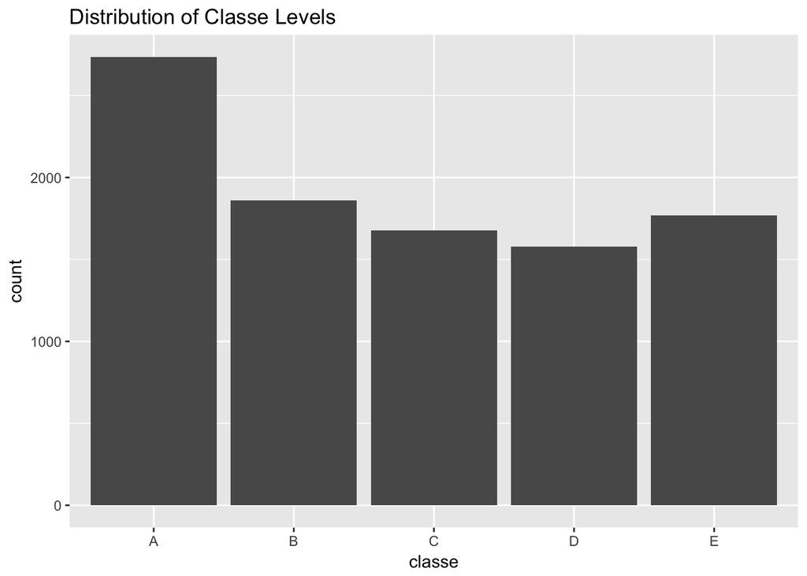

```r
ggplot(data = training, aes(x = classe)) +
  geom_histogram(stat = "count") +
  labs(title = "Distribution of Classe Levels")
```

Is there any evidence that `total_accel_belt` and `total_accel_arm` explain the variation in the `classe` variable? `total_accel_belt` values above 20 appear to be mostly Es. Similarly, `total_accel_belt` values between 5 and 10 appear to be mostly Ds.

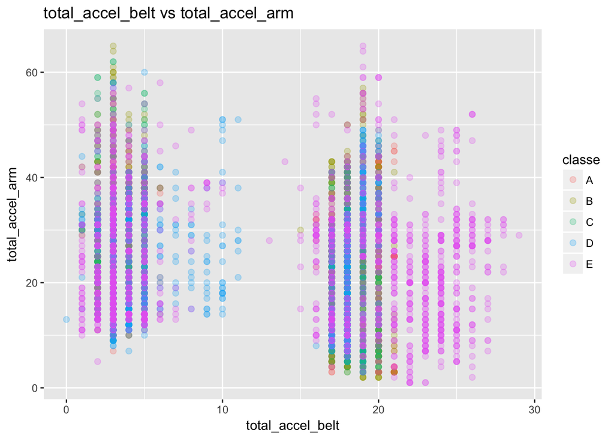

```r
ggplot(data = training, aes(x = total_accel_belt, y = total_accel_arm, color = classe)) +
  geom_point(alpha = .25, size = 2) +
  labs(title = "total_accel_belt vs total_accel_arm")
```

## How the Model Was Built

Before selecting a final model, I fit a random forest model and a bagging model on the `training` set and tested each model fit using the `testing` set. I used accuracy as the score to evaluate the effectiveness of each model. I selected the model with the best accuracy and predicted results and estimate of out of sample error using the validation dataset.

## Random Forest Model

The first model is a random forest model:

```r
fit_rf <- randomForest(classe ~ ., data = training)
```

This model was .9925 accurate in predicting `classe` using the testing model.

```r
confusionMatrix(predict(fit_rf, testing), testing$classe)
```

```
## Confusion Matrix and Statistics
##
##           Reference
## Prediction    A    B    C    D    E
##          A 1170    6    0    0    0
##          B    1  789    8    0    0
##          C    0    2  710   11    0
##          D    0    0    0  662    1
##          E    0    0    0    2  756
##
## Overall Statistics
##
##                Accuracy : 0.9925
##                  95% CI : (0.9893, 0.9949)
##     No Information Rate : 0.2844
##     P-Value [Acc > NIR] : < 2.2e-16
##
##                   Kappa : 0.9905
##  Mcnemar's Test P-Value : NA
##
## Statistics by Class:
##
##                      Class: A Class: B Class: C Class: D Class: E
## Sensitivity            0.9991   0.9900   0.9889   0.9807   0.9987
## Specificity            0.9980   0.9973   0.9962   0.9997   0.9994
## Pos Pred Value         0.9949   0.9887   0.9820   0.9985   0.9974
## Neg Pred Value         0.9997   0.9976   0.9976   0.9962   0.9997
## Prevalence             0.2844   0.1935   0.1744   0.1639   0.1838
## Detection Rate         0.2841   0.1916   0.1724   0.1608   0.1836
## Detection Prevalence   0.2856   0.1938   0.1756   0.1610   0.1841
## Balanced Accuracy      0.9986   0.9936   0.9925   0.9902   0.9990
```

## Bagging Model

The next model was fit using the bagging algorithm.

```r
fit_bag <- train(classe ~ ., method = "treebag", data = training)
```

This model was .9784 accurate in predicting `classe` using the testing model.

```r
confusionMatrix(predict(fit_bag, testing), testing$classe)
```

```
## Confusion Matrix and Statistics
##
##           Reference
## Prediction    A    B    C    D    E
##          A 1164   12    1    5    0
##          B    4  767   14    5    6
##          C    2   13  701    8    3
##          D    1    5    2  653    4
##          E    0    0    0    4  744
##
## Overall Statistics
##
##                Accuracy : 0.9784
##                  95% CI : (0.9735, 0.9826)
##     No Information Rate : 0.2844
##     P-Value [Acc > NIR] : < 2.2e-16
##
##                   Kappa : 0.9727
##  Mcnemar's Test P-Value : NA
##
## Statistics by Class:
##
##                      Class: A Class: B Class: C Class: D Class: E
## Sensitivity            0.9940   0.9624   0.9763   0.9674   0.9828
## Specificity            0.9939   0.9913   0.9924   0.9965   0.9988
## Pos Pred Value         0.9848   0.9636   0.9642   0.9820   0.9947
## Neg Pred Value         0.9976   0.9910   0.9950   0.9936   0.9961
## Prevalence             0.2844   0.1935   0.1744   0.1639   0.1838
## Detection Rate         0.2827   0.1863   0.1702   0.1586   0.1807
## Detection Prevalence   0.2870   0.1933   0.1765   0.1615   0.1816
## Balanced Accuracy      0.9940   0.9768   0.9843   0.9820   0.9908
```

## Expected Out of Sample Error

Based on these results I’ve selected the random forest model. We can estimate the out of sample error of the random forest model by predicting `classe` using the validation dataset.

```r
confusionMatrix(predict(fit_rf, validation), validation$classe)
```

```
## Confusion Matrix and Statistics
##
##           Reference
## Prediction    A    B    C    D    E
##          A 1667    7    0    0    0
##          B    5 1128   14    0    0
##          C    1    4 1011   11    2
##          D    0    0    1  950    2
##          E    1    0    0    3 1078
##
## Overall Statistics
##
##                Accuracy : 0.9913
##                  95% CI : (0.9886, 0.9935)
##     No Information Rate : 0.2845
##     P-Value [Acc > NIR] : < 2.2e-16
##
##                   Kappa : 0.989
##  Mcnemar's Test P-Value : NA
##
## Statistics by Class:
##
##                      Class: A Class: B Class: C Class: D Class: E
## Sensitivity            0.9958   0.9903   0.9854   0.9855   0.9963
## Specificity            0.9983   0.9960   0.9963   0.9994   0.9992
## Pos Pred Value         0.9958   0.9834   0.9825   0.9969   0.9963
## Neg Pred Value         0.9983   0.9977   0.9969   0.9972   0.9992
## Prevalence             0.2845   0.1935   0.1743   0.1638   0.1839
## Detection Rate         0.2833   0.1917   0.1718   0.1614   0.1832
## Detection Prevalence   0.2845   0.1949   0.1749   0.1619   0.1839
## Balanced Accuracy      0.9971   0.9932   0.9908   0.9924   0.9977
```

## Predictions On `test_df`

Finally, we’ll use the random forest model fit to create a vector of predicted values using the testing dataframe as it’s input.

```r
data.frame(number = c(1:20), pred = predict(fit_rf, test_df))
```

```
##    number pred
## 1       1    B
## 2       2    A
## 3       3    B
## 4       4    A
## 5       5    A
## 6       6    E
## 7       7    D
## 8       8    B
## 9       9    A
## 10     10    A
## 11     11    B
## 12     12    C
## 13     13    B
## 14     14    A
## 15     15    E
## 16     16    E
## 17     17    A
## 18     18    B
## 19     19    B
## 20     20    B
```